```r
library(readr)
library(ggplot2)
library(ggthemes)
source('function_library.R')
source('kalman_2.R')
```

# Apply models to simulated data

Simulate an autoregressive function + noise n times. Then run kalman filtering algorithm on it. Results2 runs kalman filtering on a single simulation but varies the noise parameter W.
$$Y = 0.7Y_{t-1} + 0.3Y_{t-2} + \eta$$

```r
#Guess parameters
ORDER <- 2
W = diag(ORDER) * 1e-7
# Initial state estimate
theta = rep(1/ORDER, ORDER)
P = diag(ORDER) * 100

# Run kalman filtering many times and cbind
ntimes <- 10
ntimes2 <- 5
results <- data.frame()
RMSE <- matrix(NA, nrow = ntimes, ncol = ntimes2 * 2)
for (i in 1:ntimes) {
    # Generate test data
    targets <- simulation(300, c(.3,.7), 1, .1)
    for (j in 1:ntimes2) {
        # Set tuning parameters
        V <- autoregression(targets, ORDER)$variance
        W = diag(ORDER) * 1 * 10 ^ ((j - 1 - round((ntimes2-1)/2)) * 2)

        kal <- kalman(targets, ORDER, V, W, theta, P)
        kal$simulation.id <- i
        kal$W <- W[1,1]
        kal$index <- 1:nrow(kal)
        results <- rbind(results, kal)

        #RMSE
        RMSE[i,j] <- sqrt(sum(autoregression(targets, ORDER)$residuals^2) / length(targets))
        RMSE[i,j + ntimes2] <- sqrt(sum( (kal$targets - kal$Estimate)^2, na.rm = T ) / length(targets))
    }
}
results <- na.omit(results)
results$simulation.id <- as.factor(results$simulation.id)
results$W <- as.factor(results$W)
```

## Make plots of simulation data

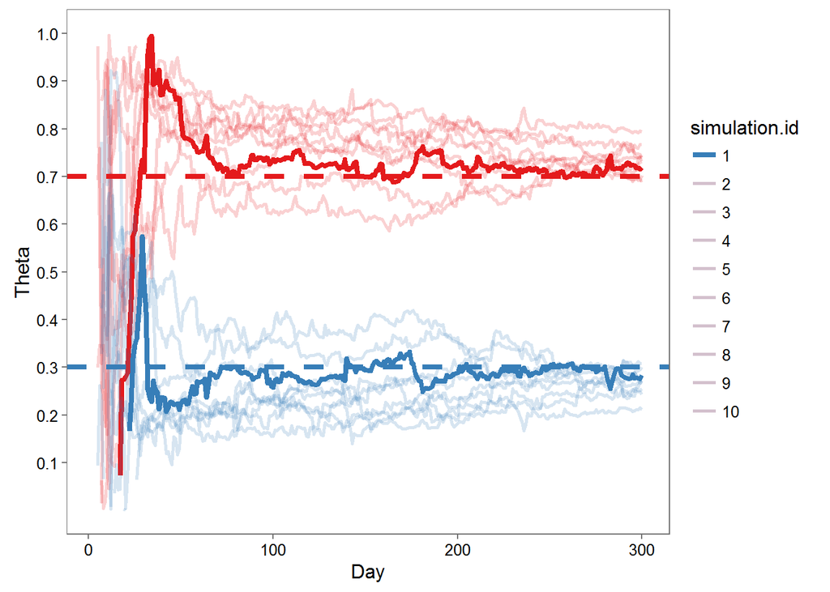

```r
colors <- RColorBrewer::brewer.pal(4, name = "Set1")

dat1 <- results[results$W == 0.0001,]
# Plot kalman filter approximation of weights
gg <- ggplot(data = dat1, aes(x = index, group = simulation.id)) +
    geom_line(aes(y = Theta1, size = simulation.id, alpha = simulation.id), col = colors[1]) +
    geom_line(aes(y = Theta2, size = simulation.id, alpha = simulation.id), col = colors[2]) +
    theme_few() +
    geom_hline(yintercept = .3, col = colors[2], linetype = 2, size = 1.5) +
    geom_hline(yintercept = .7, col = colors[1], linetype = 2, size = 1.5) +
    scale_y_continuous(breaks = seq(.1, 1, .1), limits = c(0,1)) +
    scale_size_manual(values = c(1.5, rep(1, ntimes - 1))) +
    scale_alpha_manual(values = c(1, rep(.2, ntimes - 1))) +
    ylab("Theta") +
    xlab("Day")

png("Test_Weight_Estimation.png")
gg
invisible(dev.off())
gg
```

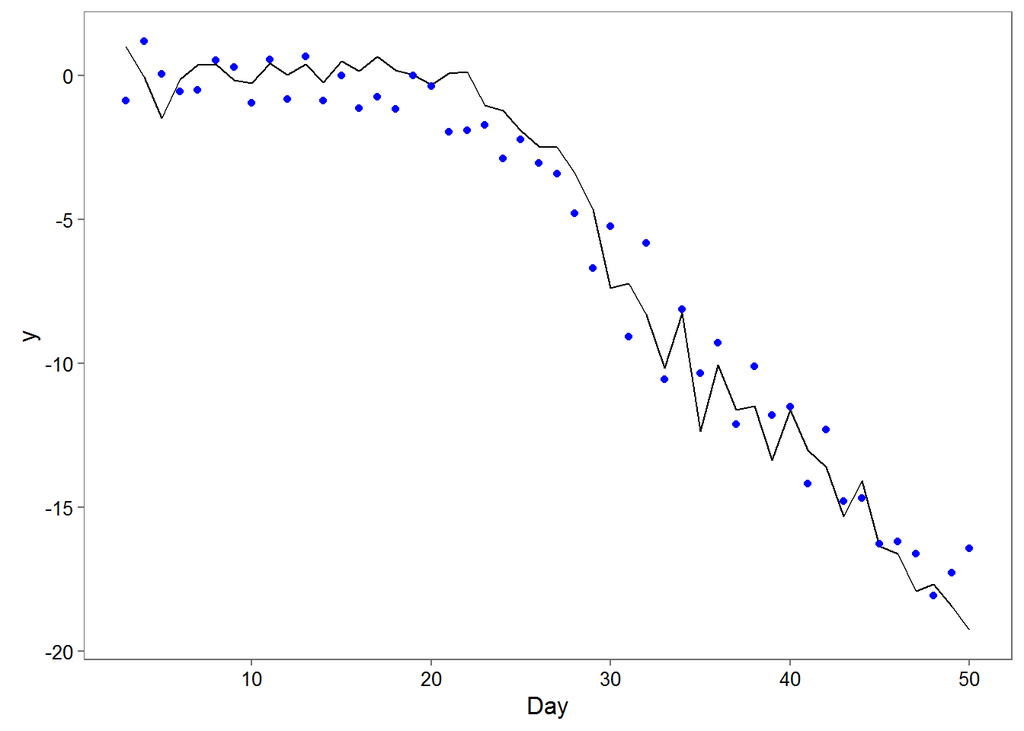

```r
# Plot kalman filter smoothing of data
dat2 <- results[(results$index %in% 1:50) & results$simulation.id == "1" & results$W == 0.0001,]
gg2 <- ggplot(data = dat2, aes(x = index)) +
    geom_line(aes(y = Estimate)) +
    geom_point(aes(y = targets), col = "blue") +
    ylab("y") +
    xlab("Day") +
    theme_few()

png("Test_Estimation.png")
gg2
invisible(dev.off())
gg2
```

### W variaiton plot

The shape of W also has an impact (but use diagonal matrix here) Lower orders of magnitude are “smoother”, on a static function like this one more smoothing improves filtering but takes longer to “lock on” to the function. For the real data where the underlying function is not static this can lead to “chasing the dragon” where the underlying function changes faster than it is locked onto.

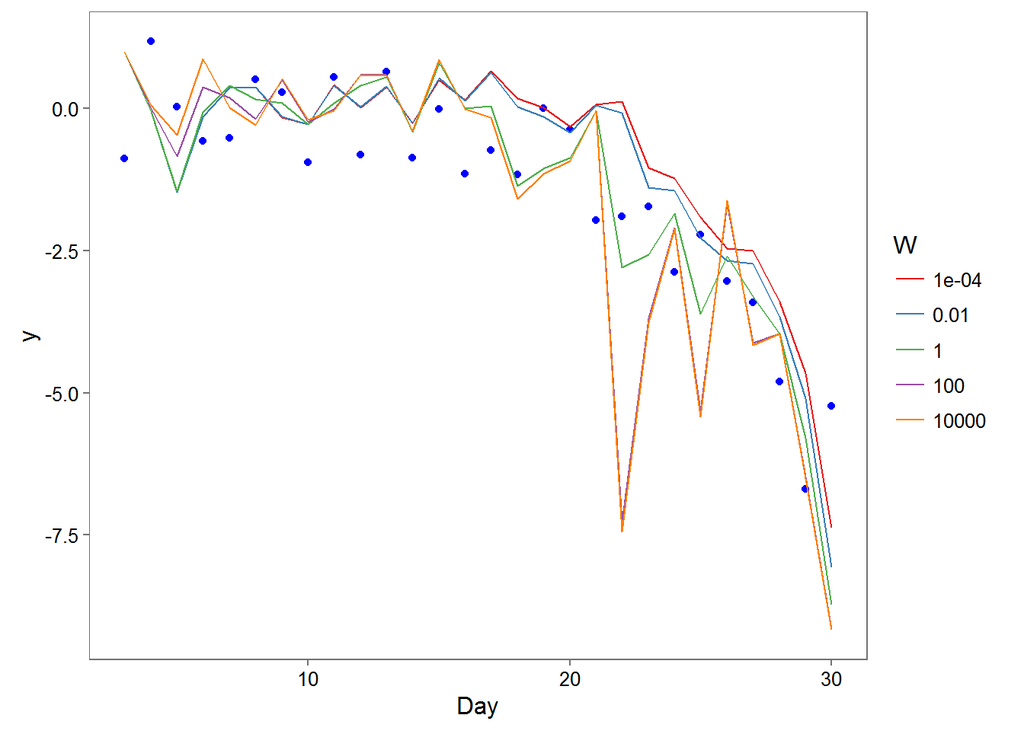

```r
# variation in W order of magnitude
dat3 <- results[(results$index %in% 1:30) & results$simulation.id == "1",]
gg3 <- ggplot(data = dat3, aes(x = index, colour = W)) +
    geom_point(aes(y = targets), col = "blue") +
    geom_line(aes(y = Estimate)) +
    ylab("y") +
    xlab("Day") +
    theme_few() +
    scale_color_brewer(palette = "Set1")

png("W_variation.png")
gg3
invisible(dev.off())
gg3
```

# REAL DATA

```r
dat_raw <- read_csv("S&P1999-2009.csv")
targets <- (dat_raw$Close)
```

```r
results_real <- data.frame()
ntimes2 = 20
w.vals <- (1 * 10) ^ (ceiling(-ntimes2/2):floor(ntimes2/2))
RMSE_real <- matrix(NA, nrow = ntimes2, ncol = length(w.vals) + 1)
for (i in 1:ntimes2) {
    # Guess parameters
    ORDER <- i
    AR_model <- autoregression(targets, ORDER)
    V <- AR_model$variance

    for (j in 1:length(w.vals)) {
        W = diag(ORDER) * w.vals[j]

        # Initial state estimate
        theta = rep(1/ORDER, ORDER)
        P = diag(ORDER) * 1e-3

        # Kalman
        kal <- kalman(targets, ORDER, V, W, theta, P)
        kal$index <- 1:nrow(kal)
        kal$order <- ORDER
        kal$W <- W[1,1]
        kal <- kal[,-c(grep("^P[0-9]*$", names(kal)))]
        kal <- kal[,-c(grep("^Theta[0-9]*$", names(kal)))]


        results_real <- rbind(results_real, kal)

        RMSE_real[i,j] <-  sqrt( sum((kal$targets - kal$Estimate)^2, na.rm = T) / length(targets) )
    }
    RMSE_real[i, length(w.vals) + 1] <- sqrt(sum(AR_model$residuals^2) / length(targets))

}
colnames(RMSE_real) <- c(paste0("w", w.vals), "AR")
rownames(RMSE_real) <- c(paste0("Order", 1:ntimes2))
```